# exp1_analysis

2023-04-27

```r
library(tidyverse)
library(tidyr)
library(rstatix)
library(data.table)
library(afex)
library(emmeans)
library(psych)
library(ggprism)
library(patchwork)
library(magrittr)
library(cowplot)
```

```r
pilot <- read_csv("pilot_final.csv", show_col_types = FALSE)
```

Changed the value of column relative_hp_dist and changed RT column to milliseconds. Tried mutate and transform functions to no avail.

```r
pilot$relative_hp_dist[pilot$relative_hp_dist == 10] <- "no_dist"
pilot$relative_hp_dist[pilot$relative_hp_dist == 0] <- "dist_0"
pilot$relative_hp_dist[pilot$relative_hp_dist == 1] <- "dist_1"
pilot$relative_hp_dist[pilot$relative_hp_dist == 2] <- "dist_2"
pilot$relative_hp_dist[pilot$relative_hp_dist == 3] <- "dist_3"

pilot$RT <- pilot$RT *1000
```

Add the block number to each trial because later I’ll examine the block by block differences.

```r
block_num <- rep(c(1,2,3,4,5,6,7,8), each=60, times=21)
pilot <- cbind(pilot, block_num)
```

### Trim the Data

Define trimming criteria according to Van Selst and Jolicoeur 1994.

```r
xsize <- c(4, 5, 6, 7, 8, 9, 10, 11, 12, 13, 14, 15, 20,
             25, 30, 35, 50, 100)
stds <- c(1.458, 1.68, 1.841, 1.961, 2.05, 2.12, 2.173,
            2.22, 2.246, 2.274, 2.31, 2.326, 2.391, 2.41, 2.4305,
            2.45, 2.48, 2.5)
```

Trim the data and compute the percent trimmed

```r
trimmed <- pilot[pilot$acc==100, ] %>% group_by(ID, relative_hp_dist) %>%
           mutate(sdc = ifelse(length(RT)>=100,2.5,approx(xsize,stds,xout=length(RT))$y), avg = mean(RT), stdev = sd(RT)) %>%
           filter(RT <= sdc*stdev+avg & RT >=avg-(sdc*stdev) & RT >=.200) %>%
           select(ID, relative_hp_dist, RT, block_num) %>%  #keep these columns in the new data frame
           as.data.frame()


statPrep <- trimmed %>% group_by(ID, relative_hp_dist) %>% summarise(measurement=mean(RT)) %>% as.data.frame()
```

```
## argument.
```

```r
100-(nrow(trimmed)/nrow(pilot[pilot$acc==100, ]))*100
```

```
## [1] 2.509732
```

2.51% of trials were trimmed.

### Graph Distractor Location RTs

```r
sum_stats <- trimmed%>%
  group_by(relative_hp_dist)%>%
  summarize(mean_rts=mean(RT),
            sd_rt=sd(RT),
            n_rt=21,
            se=sd_rt/sqrt(n_rt),
            upper_limit=mean_rts+se,
            lower_limit=mean_rts-se
  )
sum_stats
```

```
## # A tibble: 5 × 7
##   relative_hp_dist mean_rts sd_rt  n_rt    se upper_limit lower_limit
##   <chr>               <dbl> <dbl> <dbl> <dbl>       <dbl>       <dbl>
## 1 dist_0               860.  266.    21  58.1        918.        802.
## 2 dist_1               923.  277.    21  60.4        983.        862.
## 3 dist_2               926.  262.    21  57.1        984.        869.
## 4 dist_3               906.  239.    21  52.1        958.        854.
## 5 no_dist              781.  215.    21  46.9        828.        734.
```

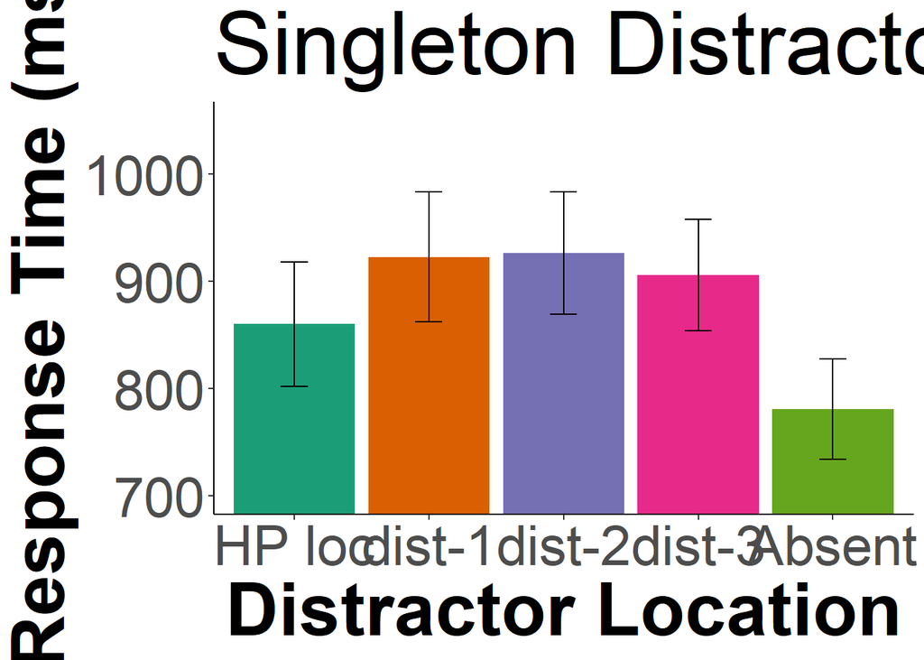

```r
a<-ggplot(data = sum_stats, aes(x = relative_hp_dist, y = mean_rts, fill=relative_hp_dist)) +
  #geom_point()+
  geom_bar(stat = "identity", show.legend = FALSE) +
  geom_errorbar(aes(ymin=lower_limit, ymax=upper_limit), width=0.2)+
  coord_cartesian(ylim = c(700,1050))+
  theme_classic()+
  scale_fill_brewer(palette="Dark2") +
  labs(x = "Distractor Location", y = "Response Time (ms)")+
  labs(title = "Singleton Distractor Present")+
  #labs(caption = "An ANOVA test shows a difference in RT depending on distractor location, F(3.28,65.57)=33.3, p<.001.")+
  theme(axis.text=element_text(size=30),
        axis.title=element_text(size=40,face="bold"),
        title = element_text(size = 40))+
  scale_x_discrete(labels= c("no_dist"="Absent","dist_0"="HP loc","dist_1"="dist-1","dist_2"="dist-2","dist_3"="dist-3"))

a
```

###Regression on each ppt for distance from HP location

```r
space <- trimmed %>%
  group_by(ID, relative_hp_dist) %>%
  summarize(rts = mean(RT)
            )
```

```
## argument.
```

```r
space
```

```
## # A tibble: 105 × 3
## # Groups:   ID [21]
##       ID relative_hp_dist   rts
##    <dbl> <chr>            <dbl>
##  1    11 dist_0           1277.
##  2    11 dist_1           1324.
##  3    11 dist_2           1336.
##  4    11 dist_3           1230.
##  5    11 no_dist          1081.
##  6    12 dist_0            799.
##  7    12 dist_1            841.
##  8    12 dist_2            849.
##  9    12 dist_3            882.
## 10    12 no_dist           732.
## # … with 95 more rows
```

Restructure data

```r
space_anova <- setDT(space)
space_anova <- dcast(space_anova,ID~relative_hp_dist,value.var='rts')
```

```r
space_anova2<-space_anova%>%
  subset(select = c(ID, dist_0, dist_1, dist_2, dist_3))
```

Set up and run regression for each ppt based on RTs for each location.

```r
design.mat <- cbind(1,2:5)
response.mat <- t(space_anova2[,2:5])
```

```r
reg <- lm.fit(design.mat, response.mat)$coefficients
data <- cbind(space_anova, t(reg))
```

T-test to see if the slopes for each ppt are different than 0. Slopes are different than 0.

```r
t.test(data$x2)
```

```
##
##  One Sample t-test
##
## data:  data$x2
## t = 2.7175, df = 20, p-value = 0.01326
## alternative hypothesis: true mean is not equal to 0
## 95 percent confidence interval:
##   3.128337 23.793936
## sample estimates:
## mean of x
##  13.46114
```

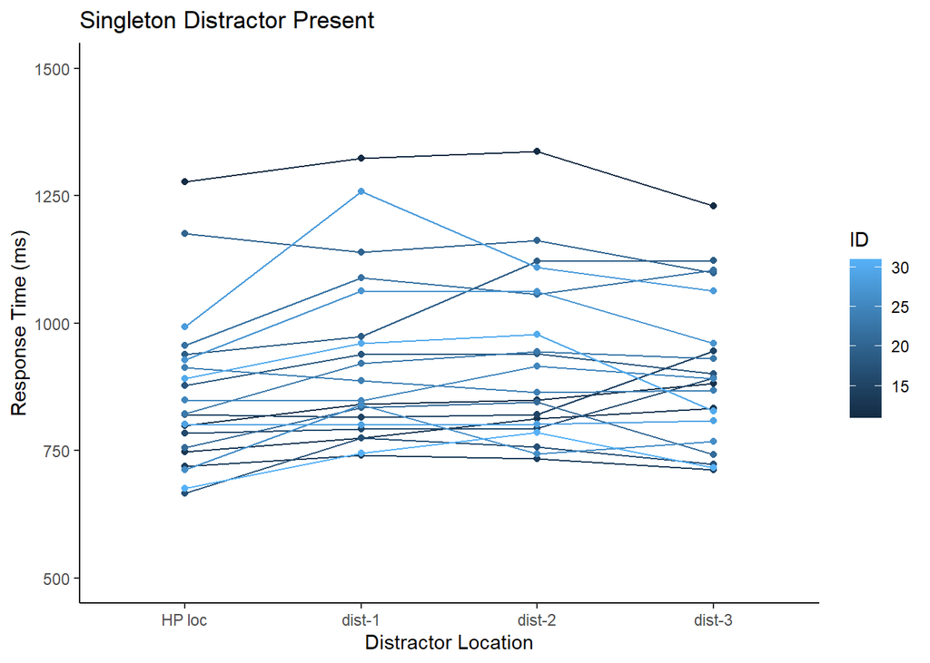

```r
space2<-space%>%
  filter(relative_hp_dist!="no_dist")

z<-ggplot(data = space2,aes(x = relative_hp_dist, y = rts, group=ID, color=ID)) +
  geom_line() +
  geom_point()+
  #geom_errorbar(aes(ymin=lower_limit, ymax=upper_limit), width=0.2)+
  coord_cartesian(ylim = c(500,1500))+
  theme_classic()+
  scale_fill_brewer(palette="Dark2") +
  labs(x = "Distractor Location", y = "Response Time (ms)")+
  labs(title = "Singleton Distractor Present")+
  #labs(caption = "An ANOVA test shows a difference in RT depending on distractor location, F(3.28,65.57)=33.3, p<.001.")+
  #theme(axis.text=element_text(size=30),
        #axis.title=element_text(size=40,face="bold"),
        #title = element_text(size = 40))+
  scale_x_discrete(labels= c("no_dist"="Absent","dist_0"="HP loc","dist_1"="dist-1","dist_2"="dist-2","dist_3"="dist-3"))

z
```

### Exploring Priming

```r
prime<-pilot%>%
  filter(relative_hp_dist!="no_dist")
```

```r
prime<-prime%>%
  mutate(trial_type=
           case_when(relative_hp_dist=="dist_0" & lag(relative_hp_dist)=="dist_0" ~ "high-high",
                     relative_hp_dist=="dist_0" & lag(relative_hp_dist)=="dist_1" ~ "low-high",
                     relative_hp_dist=="dist_0" & lag(relative_hp_dist)=="dist_2" ~ "low-high",
                     relative_hp_dist=="dist_0" & lag(relative_hp_dist)=="dist_3" ~ "low-high",

           ))
```

Get rid of NA trials

```r
prime1 <- prime%>%
  na.omit(prime)%>%
  subset(select=c(ID, acc, trial_type, block_num, RT))
```

```r
prime1<-prime1%>%
  mutate(block_num=
           case_when(block_num==1 ~1,
                     block_num==2 ~1,
                     block_num==3 ~1,
                     block_num==4 ~1,
                     block_num==5 ~2,
                     block_num==6 ~2,
                     block_num==7 ~2,
                     block_num==8 ~2,

           ))
```

Trim

```r
trim_prime <- prime1[prime1$acc==100, ]%>% group_by(ID, trial_type, block_num) %>%
           mutate(sdc = ifelse(length(RT)>=100,2.5,approx(xsize,stds,xout=length(RT))$y), avg = mean(RT), stdev = sd(RT)) %>%
           filter(RT <= sdc*stdev+avg & RT >=avg-(sdc*stdev) & RT >=.200) %>%
           select(ID, RT, block_num, trial_type) %>%  #keep these columns in the new data frame
           as.data.frame()


statPrep <- trim_prime %>% group_by(ID, trial_type, block_num) %>% summarise(measurement=mean(RT)) %>% as.data.frame()
100-(nrow(trim_prime)/nrow(prime1[prime1$acc==100, ]))*100
```

```
## [1] 2.453235
```

Trimmed 2.5% of trials.

```r
prime_anova<-trim_prime%>%
  group_by(ID, block_num, trial_type)%>%
  summarize(rt=mean(RT))
```

2-way ANOVA with block number and trial type (high-high or low-high) as factors.

```r
model <- aov_ez("ID", "rt", prime_anova, between=NULL, within = c("block_num", "trial_type"))

model
```

```
## Anova Table (Type 3 tests)
##
## Response: rt
##                 Effect    df     MSE         F   ges p.value
## 1            block_num 1, 20 4600.10 99.56 ***  .181   <.001
## 2           trial_type 1, 20 2750.66      0.07 <.001    .791
## 3 block_num:trial_type 1, 20 2082.50      1.01  .001    .326
## ---
## Signif. codes:  0 '***' 0.001 '**' 0.01 '*' 0.05 '+' 0.1 ' ' 1
```

Plot the above data

```r
y<-ggplot(data = prime_anova, aes(x = block_num, y = rt, fill=trial_type)) +
  geom_bar(stat = "summary", position= position_dodge(), show.legend = TRUE) +
  coord_cartesian(ylim = c(700,1050))+
  theme_classic()
```

###Distractor Location ANOVA

```r
aov_ez("ID", "rts", space, between=NULL, within = c("relative_hp_dist"))
```

```
## Anova Table (Type 3 tests)
##
## Response: rts
##             Effect          df     MSE         F  ges p.value
## 1 relative_hp_dist 3.28, 65.57 2806.06 33.30 *** .120   <.001
## ---
## Signif. codes:  0 '***' 0.001 '**' 0.01 '*' 0.05 '+' 0.1 ' ' 1
##
## Sphericity correction method: GG
```

```r
aov_ez("ID", "rts", space2, between=NULL, within = c("relative_hp_dist"))
```

```
## Anova Table (Type 3 tests)
##
## Response: rts
##             Effect          df     MSE        F  ges p.value
## 1 relative_hp_dist 2.50, 50.10 2820.39 7.55 *** .026   <.001
## ---
## Signif. codes:  0 '***' 0.001 '**' 0.01 '*' 0.05 '+' 0.1 ' ' 1
##
## Sphericity correction method: GG
```

```r
space %>%
  pairwise_t_test(
    rts ~ relative_hp_dist, paired = TRUE,
    p.adjust.method = "holm"
    )
```

```
## # A tibble: 10 × 10
##    .y.   group1 group2     n1    n2 statistic    df            p   p.adj p.adj…¹
##  * <chr> <chr>  <chr>   <int> <int>     <dbl> <dbl>        <dbl>   <dbl> <chr>
##  1 rts   dist_0 dist_1     21    21    -3.94     20      8.01e-4 4   e-3 **
##  2 rts   dist_0 dist_2     21    21    -5.11     20      5.31e-5 3.19e-4 ***
##  3 rts   dist_0 dist_3     21    21    -2.84     20      1   e-2 4   e-2 *
##  4 rts   dist_0 no_dist    21    21     7.01     20      8.48e-7 5.94e-6 ****
##  5 rts   dist_1 dist_2     21    21    -0.270    20      7.9 e-1 8   e-1 ns
##  6 rts   dist_1 dist_3     21    21     0.861    20      4   e-1 8   e-1 ns
##  7 rts   dist_1 no_dist    21    21     9.22     20      1.22e-8 1.1 e-7 ****
##  8 rts   dist_2 dist_3     21    21     1.31     20      2.04e-1 6.12e-1 ns
##  9 rts   dist_2 no_dist    21    21     9.47     20      7.89e-9 7.89e-8 ****
## 10 rts   dist_3 no_dist    21    21     7.97     20      1.24e-7 9.92e-7 ****
## # … with abbreviated variable name ¹p.adj.signif
```

### Distractor Location Accuracy

```r
spaceT <- pilot %>%
  group_by(ID, relative_hp_dist)%>%
  summarize(acc = mean(acc)
            )
```

```
## argument.
```

```r
space_anovaT <- setDT(spaceT)
space_anovaT <- dcast(space_anovaT,ID~relative_hp_dist,value.var='acc')

space_anovaT <- space_anovaT %>%
  mutate(low_prob = (dist_1+dist_2+dist_3)/3)

df_mod_dist <- subset(space_anovaT, select=c(ID,dist_0, low_prob,no_dist))
df_mod_dist <- reshape2::melt(df_mod_dist, id.var=c('ID'), variable.name= "relative_hp_dist")
```

ANOVA test for differences between 4 distractor locations and absent

```r
aov_ez("ID", "acc", spaceT, between=NULL, within = c("relative_hp_dist"))
```

```
## Anova Table (Type 3 tests)
##
## Response: acc
##             Effect          df   MSE      F  ges p.value
## 1 relative_hp_dist 1.32, 26.40 53.31 3.24 + .083    .073
## ---
## Signif. codes:  0 '***' 0.001 '**' 0.01 '*' 0.05 '+' 0.1 ' ' 1
##
## Sphericity correction method: GG
```

ANOVA test for differences between HP, LP, and absent conditions.

```r
aov_ez("ID", "value", df_mod_dist, between=NULL, within = c("relative_hp_dist"))
```

```
## Anova Table (Type 3 tests)
##
## Response: value
##             Effect          df  MSE         F  ges p.value
## 1 relative_hp_dist 1.18, 23.61 7.09 12.74 *** .160   <.001
## ---
## Signif. codes:  0 '***' 0.001 '**' 0.01 '*' 0.05 '+' 0.1 ' ' 1
##
## Sphericity correction method: GG
```

```r
sum_statsT <- spaceT%>%
  group_by(relative_hp_dist)%>%
  summarize(mean_acc=mean(acc),
            sd_rt=sd(acc),
            n_rt=n(),
            se=sd_rt/sqrt(n_rt),
            upper_limit=mean_acc+se,
            lower_limit=mean_acc-se
  )
sum_statsT
```

```
## # A tibble: 5 × 7
##   relative_hp_dist mean_acc sd_rt  n_rt    se upper_limit lower_limit
##   <chr>               <dbl> <dbl> <int> <dbl>       <dbl>       <dbl>
## 1 dist_0               96.1  2.24    21 0.488        96.6        95.6
## 2 dist_1               95.9  2.80    21 0.612        96.5        95.3
## 3 dist_2               94.9  4.25    21 0.927        95.9        94.0
## 4 dist_3               93.5  9.58    21 2.09         95.5        91.4
## 5 no_dist              97.9  1.60    21 0.349        98.3        97.6
```

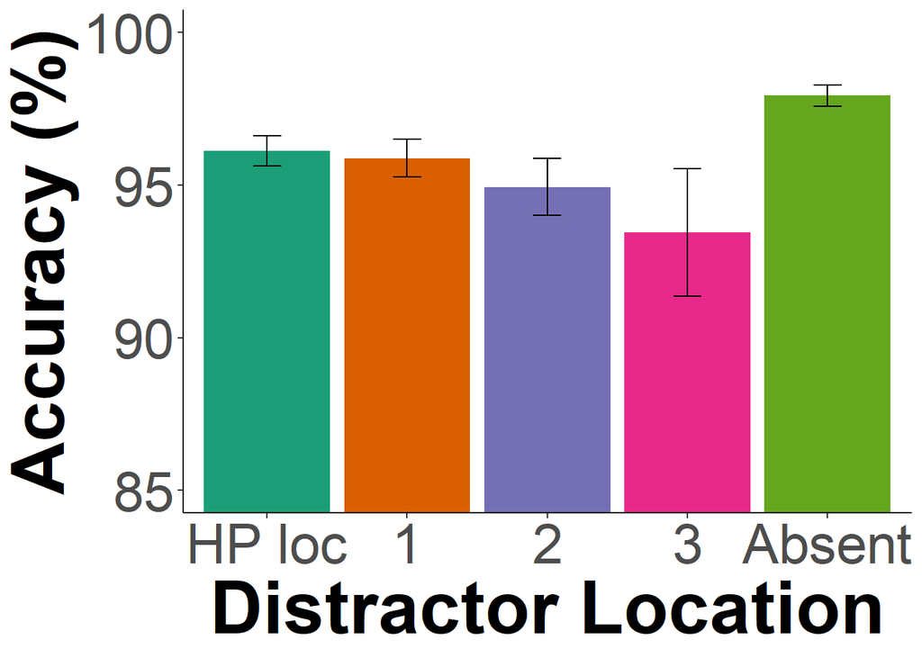

```r
b<-ggplot(data = sum_statsT, aes(x = relative_hp_dist, y = mean_acc, fill=relative_hp_dist)) +
  geom_bar(stat = "identity", show.legend = FALSE) +
  geom_errorbar(aes(ymin=lower_limit, ymax=upper_limit), width=0.2)+
  coord_cartesian(ylim = c(85,100))+
  theme_classic()+
  scale_fill_brewer(palette="Dark2")+
  labs(x = "Distractor Location", y = "Accuracy (%)")+
  #labs(title = "Distractor Location Effect on Accuracy")+
  theme(axis.text=element_text(size=30),
        axis.title=element_text(size=40,face="bold"),
        title = element_text(size = 24))+
  scale_x_discrete(labels= c("no_dist"="Absent","dist_0"="HP loc","dist_1"="1","dist_2"="2","dist_3"="3"))

b
```

### Examine block-by-block learning of distractor location

The goal of this section is to examine individual blocks of trials for learning. I’ll be taking the difference between response times when the distractor is presented in the low probability locations and response times when the distractor is presented in the high probability location in each block to see roughly how quickly individuals are learning the regularity.

```r
space_block <- trimmed %>%
  group_by(ID, block_num, relative_hp_dist) %>%
  summarize(rts = mean(RT),
            )
space_block
```

```
## # A tibble: 837 × 4
## # Groups:   ID, block_num [168]
##       ID block_num relative_hp_dist   rts
##    <dbl>     <dbl> <chr>            <dbl>
##  1    11         1 dist_0           1552.
##  2    11         1 dist_1           1361.
##  3    11         1 dist_2           1557.
##  4    11         1 dist_3           1113.
##  5    11         1 no_dist          1317.
##  6    11         2 dist_0           1405.
##  7    11         2 dist_1           1400.
##  8    11         2 dist_2           1555.
##  9    11         2 dist_3           1329.
## 10    11         2 no_dist          1127.
## # … with 827 more rows
```

```r
space_block <- setDT(space_block)
space_block <- dcast(space_block,ID+block_num~relative_hp_dist,value.var='rts')
```

Below, I added the average rt for the low probability locations and the difference between the low probability and high probability locations ignoring n/a values.

```r
space_block <- space_block %>%
  mutate(low_prob = rowMeans(select(space_block, c(dist_1,dist_2,dist_3)),na.rm=TRUE)) %>%
  mutate(difference = (low_prob-dist_0))
```

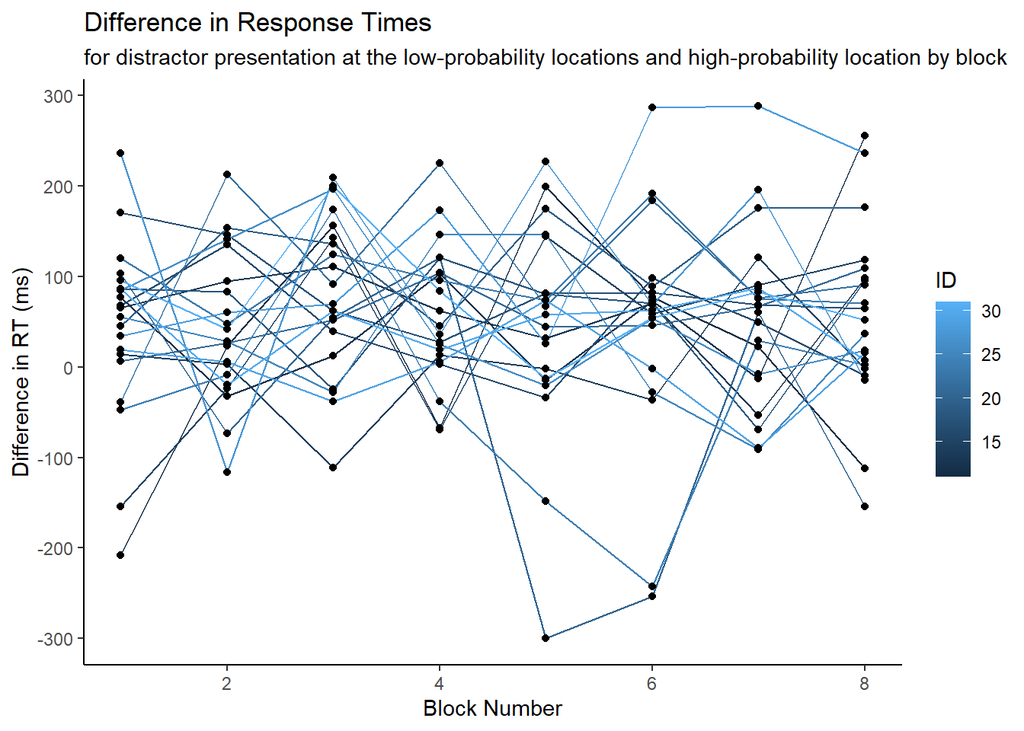

```r
ggplot(data = space_block,aes(x=block_num, y=difference, group=ID))+
  geom_line(aes(color=ID))+
  geom_point()+
  labs(title = "Difference in Response Times", subtitle = "for distractor presentation at the low-probability locations and high-probability location by block")+
  theme_classic()+
  labs(x = "Block Number", y = "Difference in RT (ms)")
```

```r
space2 <- space_block %>%
  group_by(block_num) %>%
  summarize(rts = mean(difference, na.rm = TRUE),
            sd_rt=sd(difference, na.rm = TRUE),
            n_rt=n(),
            se=sd_rt/sqrt(n_rt),
            upper_limit=rts+se,
            lower_limit=rts-se
            )
```

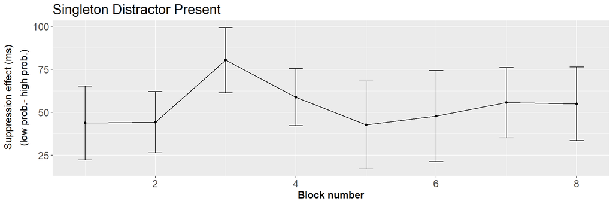

```r
ggplot(data = space2,aes(x=block_num, y=rts))+
  geom_line()+
  geom_point()+
  geom_errorbar(aes(ymin=lower_limit, ymax=upper_limit), width=0.2)+
  labs(title = "Singleton Distractor Present")+
  xlab("Block number")+
  ylab(expression(atop("Suppression effect (ms)", paste("(low prob.- high prob.)"))))+
  theme(axis.text=element_text(size=14),
        axis.title=element_text(size=14,face="bold"),
        title = element_text(size = 16))
```

```r
aov_ez("ID", "difference", space_block, between=NULL, within = c("block_num"))
```

```
## Anova Table (Type 3 tests)
##
## Response: difference
##      Effect           df      MSE    F  ges p.value
## 1 block_num 5.15, 103.07 10849.67 0.41 .015    .847
## ---
## Signif. codes:  0 '***' 0.001 '**' 0.01 '*' 0.05 '+' 0.1 ' ' 1
##
## Sphericity correction method: GG
```

###Examine Target Location Effects

```r
pilot <- read_csv("pilot_final1.csv", show_col_types = FALSE)
pilot$relative_hp_dist[pilot$relative_hp_dist == 10] <- "no_dist"
pilot$relative_hp_dist[pilot$relative_hp_dist == 0] <- "dist_0"
pilot$relative_hp_dist[pilot$relative_hp_dist == 1] <- "dist_1"
pilot$relative_hp_dist[pilot$relative_hp_dist == 2] <- "dist_2"
pilot$relative_hp_dist[pilot$relative_hp_dist == 3] <- "dist_3"
pilot$RT <- pilot$RT *1000
```

Added in the block column at this point just in case I want to use it in the future.

```r
block_num <- rep(c(1,2,3,4,5,6,7,8), each=60, times=21)
pilot <- cbind(pilot, block_num)
```

Added in a column for how the target related to the high-probability distractor location. Used brute force instead of trying to write a fancy function.

```r
pilot <- pilot %>%
  mutate(relative_target=
           case_when(target_loc=="loc1" & high_prob==1 ~ 0,
                     target_loc=="loc2" & high_prob==1 ~ 1,
                     target_loc=="loc3" & high_prob==1 ~ 2,
                     target_loc=="loc4" & high_prob==1 ~ 3,
                     target_loc=="loc5" & high_prob==1 ~ 2,
                     target_loc=="loc6" & high_prob==1 ~ 1,
                     target_loc=="loc1" & high_prob==2 ~ 1,
                     target_loc=="loc2" & high_prob==2 ~ 0,
                     target_loc=="loc3" & high_prob==2 ~ 1,
                     target_loc=="loc4" & high_prob==2 ~ 2,
                     target_loc=="loc5" & high_prob==2 ~ 3,
                     target_loc=="loc6" & high_prob==2 ~ 2,
                     target_loc=="loc1" & high_prob==3 ~ 2,
                     target_loc=="loc2" & high_prob==3 ~ 1,
                     target_loc=="loc3" & high_prob==3 ~ 0,
                     target_loc=="loc4" & high_prob==3 ~ 1,
                     target_loc=="loc5" & high_prob==3 ~ 2,
                     target_loc=="loc6" & high_prob==3 ~ 3,
                     target_loc=="loc1" & high_prob==4 ~ 3,
                     target_loc=="loc2" & high_prob==4 ~ 2,
                     target_loc=="loc3" & high_prob==4 ~ 1,
                     target_loc=="loc4" & high_prob==4 ~ 0,
                     target_loc=="loc5" & high_prob==4 ~ 1,
                     target_loc=="loc6" & high_prob==4 ~ 2,
                     target_loc=="loc1" & high_prob==5 ~ 2,
                     target_loc=="loc2" & high_prob==5 ~ 3,
                     target_loc=="loc3" & high_prob==5 ~ 2,
                     target_loc=="loc4" & high_prob==5 ~ 1,
                     target_loc=="loc5" & high_prob==5 ~ 0,
                     target_loc=="loc6" & high_prob==5 ~ 1,
                     target_loc=="loc1" & high_prob==6 ~ 1,
                     target_loc=="loc2" & high_prob==6 ~ 2,
                     target_loc=="loc3" & high_prob==6 ~ 3,
                     target_loc=="loc4" & high_prob==6 ~ 2,
                     target_loc=="loc5" & high_prob==6 ~ 1,
                     target_loc=="loc6" & high_prob==6 ~ 0,))

pilot$relative_target[pilot$relative_target == 0] <- "high_prob"
pilot$relative_target[pilot$relative_target == 1] <- "lp_1"
pilot$relative_target[pilot$relative_target == 2] <- "lp_2"
pilot$relative_target[pilot$relative_target == 3] <- "lp_3"
```

### Trim the Data

Define trimming criteria according to Van Selst and Jolicoeur 1994

```r
xsize <- c(4, 5, 6, 7, 8, 9, 10, 11, 12, 13, 14, 15, 20,
             25, 30, 35, 50, 100)
stds <- c(1.458, 1.68, 1.841, 1.961, 2.05, 2.12, 2.173,
            2.22, 2.246, 2.274, 2.31, 2.326, 2.391, 2.41, 2.4305,
            2.45, 2.48, 2.5)
```

Trim the data and compute the percent trimmed

```r
add_this<- pilot[pilot$acc==100,]

trimmed <- add_this[add_this$relative_hp_dist=="no_dist",] %>%
  group_by(ID, relative_target) %>%
           mutate(sdc = ifelse(length(RT)>=100,2.5,approx(xsize,stds,xout=length(RT))$y), avg = mean(RT), stdev = sd(RT)) %>%
           filter(RT <= sdc*stdev+avg & RT >=avg-(sdc*stdev) & RT >=.200) %>%
           select(ID, relative_hp_dist, RT, block_num, relative_target) %>%
           as.data.frame()


statPrep <- trimmed %>% group_by(ID, relative_target) %>% summarise(measurement=mean(RT)) %>% as.data.frame()
```

```
## argument.
```

```r
100-(nrow(trimmed)/nrow(add_this[add_this$relative_hp_dist=="no_dist",]))*100
```

```
## [1] 2.694489
```

```r
target_means <- trimmed %>%
  filter(relative_hp_dist=="no_dist") %>%
  group_by(relative_target) %>%
  summarize(mean_rts=mean(RT),
            sd_rt=sd(RT),
            n_rt=21,
            se=sd_rt/sqrt(n_rt),
            upper_limit=mean_rts+se,
            lower_limit=mean_rts-se
  )
target_means
```

```
## # A tibble: 4 × 7
##   relative_target mean_rts sd_rt  n_rt    se upper_limit lower_limit
##   <chr>              <dbl> <dbl> <dbl> <dbl>       <dbl>       <dbl>
## 1 high_prob           797.  221.    21  48.2        845.        749.
## 2 lp_1                782.  215.    21  46.8        829.        736.
## 3 lp_2                776.  216.    21  47.1        823.        728.
## 4 lp_3                775.  217.    21  47.2        822.        728.
```

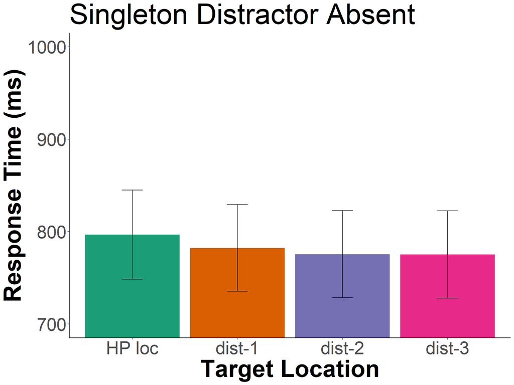

```r
c<-ggplot(data = target_means, aes(x = relative_target, y = mean_rts, fill=relative_target)) +
  geom_bar(stat = "identity", show.legend = FALSE) +
  geom_errorbar(aes(ymin=lower_limit, ymax=upper_limit), width=0.2)+
  coord_cartesian(ylim = c(700,1000))+
  theme_classic()+
  scale_fill_brewer(palette="Dark2")+
  labs(x = "Target Location", y = "Response Time (ms)")+
  labs(title = "Singleton Distractor Absent")+
  theme(axis.text=element_text(size=30),
    axis.title=element_text(size=40,face="bold"),
    title = element_text(size = 40))+
  scale_x_discrete(labels= c("high_prob"="HP loc","lp_1"="dist-1", "lp_2"="dist-2", "lp_3"="dist-3"))


c
```

```r
space <- trimmed %>%
  subset(relative_hp_dist=="no_dist")%>%
  group_by(ID, relative_target) %>%
  summarize(rts = mean(RT),
            )
```

```
## argument.
```

```r
space
```

```
## # A tibble: 84 × 3
## # Groups:   ID [21]
##       ID relative_target   rts
##    <dbl> <chr>           <dbl>
##  1    11 high_prob       1088.
##  2    11 lp_1            1083.
##  3    11 lp_2            1056.
##  4    11 lp_3            1102.
##  5    12 high_prob        801.
##  6    12 lp_1             749.
##  7    12 lp_2             701.
##  8    12 lp_3             708.
##  9    13 high_prob        748.
## 10    13 lp_1             756.
## # … with 74 more rows
```

```r
aov_ez("ID", "rts", space, between=NULL, within = c("relative_target"))
```

```
## Anova Table (Type 3 tests)
##
## Response: rts
##            Effect          df     MSE    F  ges p.value
## 1 relative_target 2.00, 40.09 1613.42 2.05 .006    .142
## ---
## Signif. codes:  0 '***' 0.001 '**' 0.01 '*' 0.05 '+' 0.1 ' ' 1
##
## Sphericity correction method: GG
```

```r
space_anova <- setDT(space)
space_anova <- dcast(space_anova,ID~relative_target,value.var='rts')
```

```r
space_anova <- space_anova %>%
  mutate(low_prob = (lp_1+lp_2+lp_3)/3)
```

```r
df_mod <- subset(space_anova, select=c(ID, high_prob, low_prob))

df_mod <- reshape2::melt(df_mod, id.var=c('ID'), variable.name= "relative_target")
```

```r
sum_stats2 <- df_mod%>%
  group_by(relative_target)%>%
  summarize(mean_rts=mean(value),
            sd_rt=sd(value),
            n_rt=n(),
            se=sd_rt/sqrt(n_rt),
            upper_limit=mean_rts+se,
            lower_limit=mean_rts-se
  )
sum_stats2
```

```
## # A tibble: 2 × 7
##   relative_target mean_rts sd_rt  n_rt    se upper_limit lower_limit
##   <fct>              <dbl> <dbl> <int> <dbl>       <dbl>       <dbl>
## 1 high_prob           797.  120.    21  26.2        823.        771.
## 2 low_prob            777.  117.    21  25.6        803.        752.
```

Determine if the difference between response times when the target is in the high-probability vs. low-probability locations is significant.

```r
t.test(x=space_anova$high_prob, y=space_anova$low_prob, alternative="greater", mu=0,paired = TRUE, conf.level = .95)
```

```
##
##  Paired t-test
##
## data:  space_anova$high_prob and space_anova$low_prob
## t = 1.8799, df = 20, p-value = 0.03738
## alternative hypothesis: true mean difference is greater than 0
## 95 percent confidence interval:
##  1.619941      Inf
## sample estimates:
## mean difference
##        19.62472
```

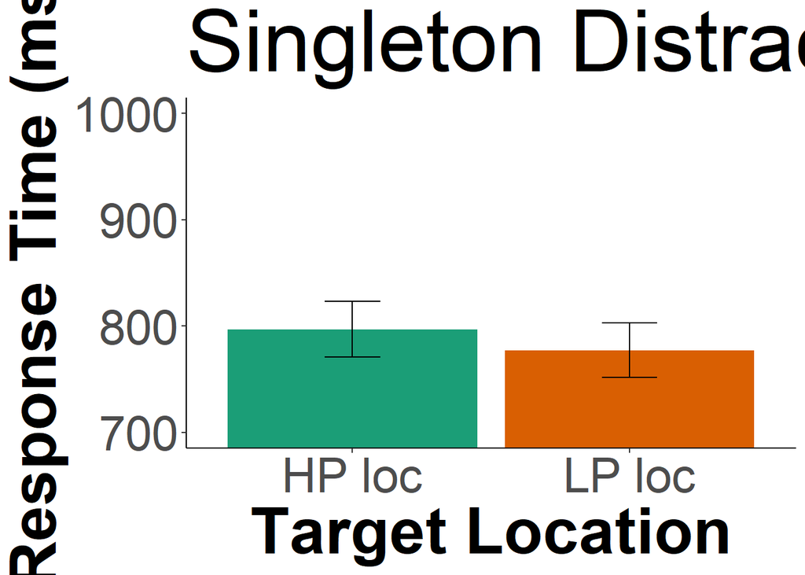

```r
sum_stats2$relative_target <- factor(sum_stats2$relative_target,              # Change ordering manually
                  levels = c("high_prob", "low_prob"))

ggplot(data = sum_stats2, aes(x = relative_target, y = mean_rts, fill=relative_target)) +
  geom_bar(stat = "identity", show.legend = FALSE) +
  geom_errorbar(aes(ymin=lower_limit, ymax=upper_limit), width=0.2)+
  coord_cartesian(ylim = c(700,1000))+
  theme_classic()+
  scale_fill_brewer(palette="Dark2") +
  labs(x = "Target Location", y = "Response Time (ms)")+
  labs(title = "Singleton Distractor Absent")+
  theme(axis.text=element_text(size=30),
        axis.title=element_text(size=40,face="bold"),
        title = element_text(size = 45))+
  scale_x_discrete(labels= c("high_prob"="HP loc","low_prob"="LP loc"))
```

###Target Location Effects on Accuracy

```r
pilot_targ <- pilot %>%
  subset(relative_hp_dist=="no_dist")%>%
  group_by(ID, relative_target) %>%
  summarize(accuracy = mean(acc)
            )
```

```
## argument.
```

```r
pilot_targ
```

```
## # A tibble: 84 × 3
## # Groups:   ID [21]
##       ID relative_target accuracy
##    <dbl> <chr>              <dbl>
##  1    11 high_prob           97.5
##  2    11 lp_1                97.5
##  3    11 lp_2                97.5
##  4    11 lp_3               100
##  5    12 high_prob          100
##  6    12 lp_1               100
##  7    12 lp_2                98.8
##  8    12 lp_3               100
##  9    13 high_prob          100
## 10    13 lp_1               100
## # … with 74 more rows
```

```r
aov_ez("ID", "accuracy", pilot_targ, between=NULL, within = c("relative_target"))
```

```
## Anova Table (Type 3 tests)
##
## Response: accuracy
##            Effect          df  MSE    F  ges p.value
## 1 relative_target 2.46, 49.12 3.77 1.21 .027    .312
## ---
## Signif. codes:  0 '***' 0.001 '**' 0.01 '*' 0.05 '+' 0.1 ' ' 1
##
## Sphericity correction method: GG
```

```r
targ_t <- setDT(pilot_targ)
targ_t <- dcast(pilot_targ,ID~relative_target,value.var='accuracy')

targ_t <- targ_t %>%
  mutate(low_prob = (lp_1+lp_2+lp_3)/3)

targ_t %>%
  t.test(x=targ_t$low_prob, y=targ_t$high_prob, alternative="greater", mu=0,paired = TRUE, conf.level = .95)
```

```
##
##  Paired t-test
##
## data:  targ_t$low_prob and targ_t$high_prob
## t = 1.2922, df = 20, p-value = 0.1055
## alternative hypothesis: true mean difference is greater than 0
## 95 percent confidence interval:
##  -0.2324223        Inf
## sample estimates:
## mean difference
##       0.6944444
```

```r
sum_targ <- pilot_targ%>%
  group_by(relative_target)%>%
  summarize(mean_acc=mean(accuracy),
            sd_rt=sd(accuracy),
            n_rt=n(),
            se=sd_rt/sqrt(n_rt),
            upper_limit=mean_acc+se,
            lower_limit=mean_acc-se
  )
sum_targ
```

```
## # A tibble: 4 × 7
##   relative_target mean_acc sd_rt  n_rt    se upper_limit lower_limit
##   <chr>              <dbl> <dbl> <int> <dbl>       <dbl>       <dbl>
## 1 high_prob           97.4  2.79    21 0.609        98.0        96.8
## 2 lp_1                97.7  1.75    21 0.382        98.1        97.4
## 3 lp_2                98.3  2.00    21 0.435        98.7        97.8
## 4 lp_3                98.2  2.39    21 0.522        98.7        97.7
```

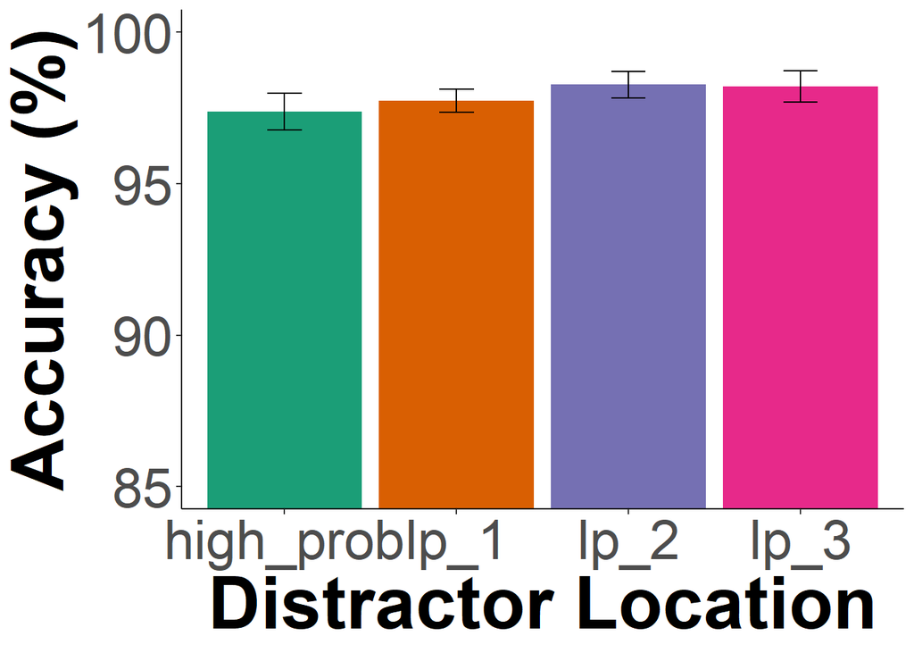

```r
d<-ggplot(data = sum_targ, aes(x = relative_target, y = mean_acc, fill=relative_target)) +
  geom_bar(stat = "identity", show.legend = FALSE) +
  geom_errorbar(aes(ymin=lower_limit, ymax=upper_limit), width=0.2)+
  coord_cartesian(ylim = c(85,100))+
  theme_classic()+
  scale_fill_brewer(palette="Dark2")+
  labs(x = "Distractor Location", y = "Accuracy (%)")+
  #labs(title = "Distractor Location Effect on Accuracy")+
  theme(axis.text=element_text(size=30),
        axis.title=element_text(size=40,face="bold"),
        title = element_text(size = 24))+
  scale_x_discrete(labels= c("no_dist"="Absent","dist_0"="HP loc","dist_1"="1","dist_2"="2","dist_3"="3"))

d
```

### Make Figures

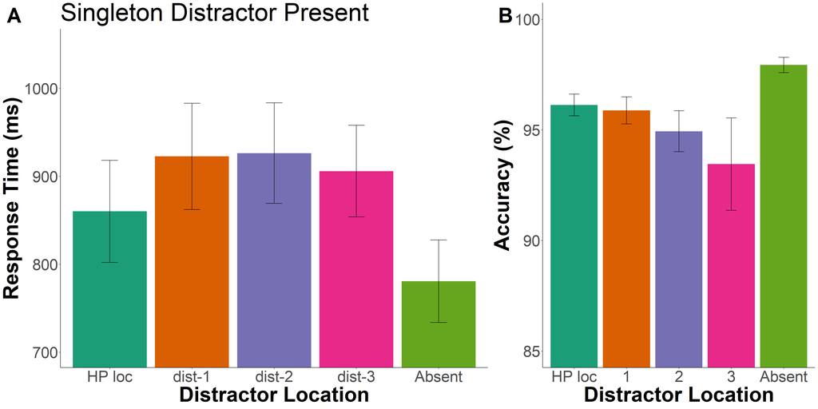

```r
plot_grid(a,b,labels = c('A','B'), label_size=40, rel_widths = c(1.5,1))
```

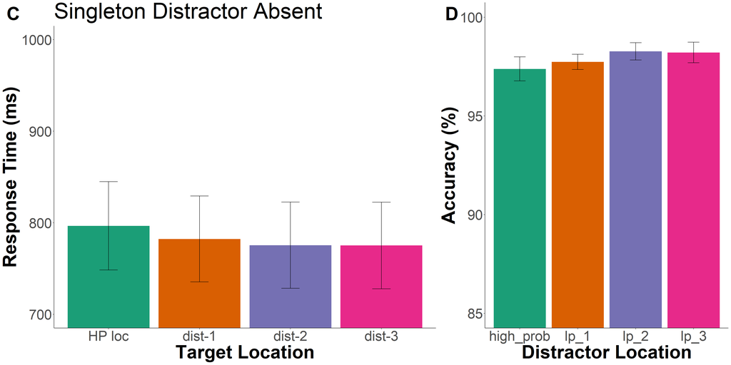

```r
plot_grid(c,d,labels = c('C','D'), label_size=40, rel_widths = c(1.5,1))
```